# Extra 回帰分析

プログラミング演習Ⅰ

佐藤 秀保

sato0035@toyo.jp

## 準備

1. [Posit Cloud](https://posit.cloud/)へ（日本語訳しないことを推奨）
2. 作成済みのプロジェクトをクリック
3. 先週使用のスクリプトをすべて閉じる
4. 新しくスクリプトを作成
5. 作成したスクリプトを保存：名前は「lecture14」
6. ほうきボタンでオブジェクトを削除
7. **library(tidyverse)を実行**
8. **questionnaire.xlsxを読込**
9. ダミー変数を作成（以下のコード）

```r
#男性ダミー、20代に比較した各年代ダミー変数の作成
df <- questionnaire %>%
  mutate(dummy_male = case_when(
    gender == "m" ~ 1,
    TRUE ~ 0),
    dummy_30 = case_when(
      age_group == "in_30" ~ 1,
      TRUE ~ 0),
    dummy_40 = case_when(
      age_group == "in_40" ~ 1,
      TRUE ~ 0),
    dummy_50 = case_when(
      age_group == "in_50" ~ 1,
      TRUE ~ 0),
    dummy_60 = case_when(
      age_group == "in_60" ~ 1,
      TRUE ~ 0),
    dummy_70 = case_when(
      age_group == "in_70" ~ 1,
      TRUE ~ 0)
    )
```

## 回帰分析 regression analysis

- 変数間の直線的（線型；linear）関係を分析
  - 下図では所得incomeと摂取カロリーcaloriesの間のあてはまりの良い線形関係を推定

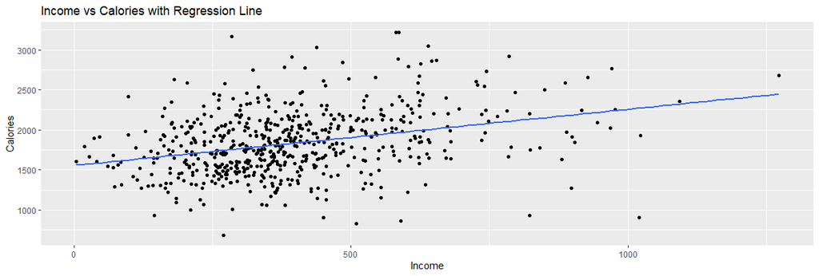

### あてはまりのよい直線を引くとは？

- 直線の方程式は y = ax + b
- 直線はaとbの値が決まれば一意に決定される
  - 例：y = 2x + 10（傾き2，縦軸切片10の直線）
- 即ち，直線を引くとは，データからa, bの値を推定すればよい
- 推定方法の代表例は最小二乗法（OLS; Ordinary Least Squares）

### OLSによる推定方法

- yは被説明変数，xは説明変数とよぶ．
- 文法：lm(y ~ x, data = データフレーム名)
  - lmはlinear model（線型モデル）の略称
  - 被説明変数 ~ 説明変数という順
  - データは回帰式の後に指定するので，データ加工後にそのままパイプでつなぐことは基本不可

  ```r
  #推定結果はres1と適当に名前を付けて保存
  res1 <- lm(calories ~ income, data = df)
  #結果の呼び出し
  res1
  ```

### 推定結果

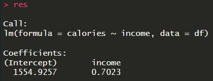

- Coefficients（係数）がa, bに該当
  - Intercept（切片）：b（縦軸切片）
  - income（説明変数名）：a（傾き）
- 解釈： y = 0.7023*x + 1554.9257
  - 所得が1万円ふえれば，摂取カロリーは平均的には0.7023kcal増える
  - 因果関係をきっちり調べるには因果推論技術が必要
    - 2年生以降授業「計量経済学」,「因果推論」,「応用計量経済学」などを確認

### **重回帰分析**

- 単回帰分析：１つの被説明変数と**１つの**説明変数の線形関係を分析
- 重回帰分析：１つの被説明変数と**複数の**説明変数の線形関係を分析
  - 例：被説明変数をcalories，説明変数をincome, dummy_male, dummy_30, dummy_40, dummy_50, dummy_60, dummy_70
- 文法：lm(y ~ x1 + x2 + x3, data = データフレーム名)
  - 複数の説明変数を「+」でつなぐ

```r
#適宜改行
res2 <- lm(calories ~ income +
             dummy_male +
             dummy_30 +
             dummy_40 +
             dummy_50 +
             dummy_60 +
             dummy_70, data = df)
res2
```

### 推定結果（重回帰）

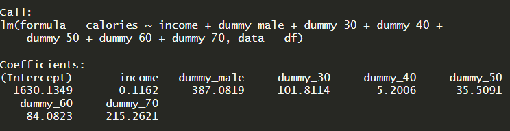

- 所得が1万円増加⇒カロリーは0.1162kcal増加
- 女性に比べて男性⇒カロリーは387.0819kcal増加
- 20代に比べて30代⇒カロリーは101.8114kcal増加
- 20代に比べて60代⇒カロリーは84.0823kcal減少

### 詳細な結果の表示

- summary関数で標準誤差，t値，p値などを表示

```r
summary(res2)
```

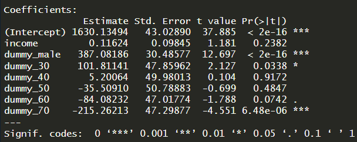

- Estimate（推定値）：係数，Std.Error：標準誤差，t value：t値，pr：p値
- 右の***などは統計的に推定結果が意味のあるものかどうかを検定している
- 性別や高齢（70歳以上）であることは，摂取カロリーに影響を及ぼしていそう